# Population and voting: at the county level

Oladipo Vanessa Dolapo

2023-09-28

# BACKGROUND:

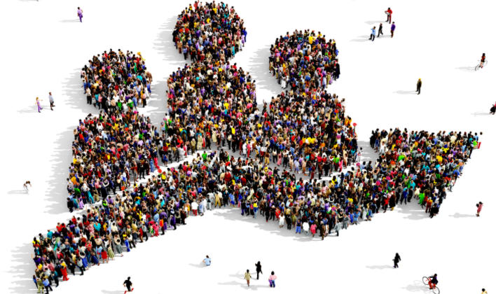

A symbolic representation of population and economy. Source: Adda247.com

# QUESTION:

Is there a relationship between the change in a county’s population and the strength of the county’s economy?

# Data Analysis:

## HYPOTHESIS

$H_o$: Change in a county’s population does not affect the strength of the county’s economy.

$H_a$: Change in a county’s population affects the strength of the county’s economy.

# Variable selection

For the T-test we need a dependent variable, for this I’m going to be using the Unemployment rate 2016 from the county’s data set (Unemployment_rate_2016: Unemployment rate, 2016)

For the independent variable I am going to be using the population from the county’s data set (PER_POP_CHG_2016: present of the population that changed between 7/1/2015 and 7/1/2016)

### Step 1: Gain an understanding of the distribution of population in American counties.

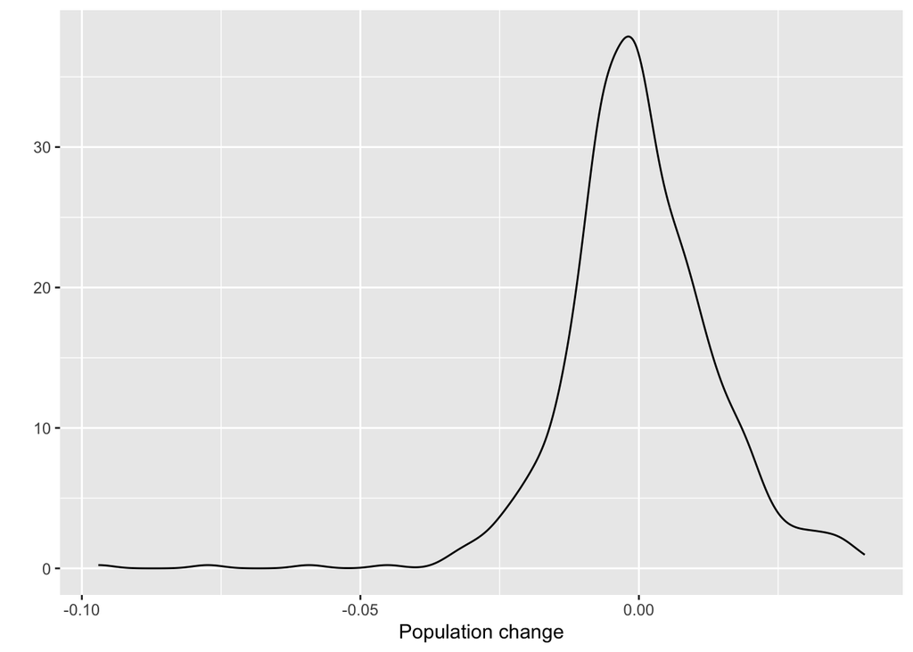

```r
ggplot(c, aes(x = PER_POP_CHG_2016)) +
  geom_density() +
xlab("Population change") +
  ylab("")
```

### Step 2: we need our dependent variable to be numeric and our independent variable to be categorical with two levels. they are both numeric.

Recoding population by filling numbers greater than zero as “GROWING” and numbers less than zero as “DECLINING”then adding the table function is to organize it appropriately.

```r
c$population_c <- NA
c$population_c[c$PER_POP_CHG_2016 >= 0] <- "GROWING"
c$population_c[c$PER_POP_CHG_2016 < 0] <- "DECLINING"

pander(table(c$population_c))
```

| DECLINING | GROWING |
| --- | --- |
| 333 | 295 |

# Discriptive analysis

See Figure 1 to compare the distributions of economy strength in growing-population counties and declining-population counties.

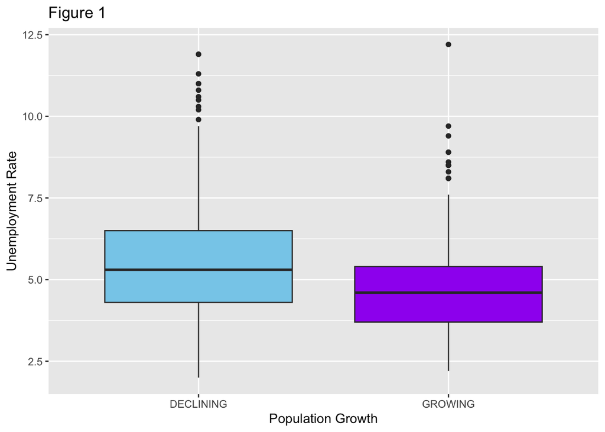

```r
ggplot(c,aes(x = population_c, y = Unemployment_rate_2016, fill = population_c)) +
  geom_boxplot() +
  scale_fill_manual(values = c( "skyblue","purple")) +
  labs(x ="Population Growth", y = "Unemployment Rate", fill = "Population Change" ) +
  ggtitle("Figure 1") +
  theme(legend.position = "")
```

### Inferential analysis

Before utilizing the two-sample T-Test, I first need to confirm that it is appropriate for this case and that all of the assumptions are met.

**Requirements / Assumptions**

1. Is the independent variable categorical with only two levels? Yes, I manipulated the data using the cut point to meet this requiriement.
2. Is the dependent variable numeric? Yes,the unemployment rate is a percent and a pure number
3. Is the sample representative of the population? The procedures in the code book yielded the fact that is representative.
4. Can the sampling distribution be assumed to be normal? We can assume normality when we have more than 30 units of analysis and from the code book sample we have more than 600.

### Creating a table with the test results

```r
test_results <- data.frame(
  Data = "Unemployment rate 2016",
  `t value` = 5.8255,
  `df` = 620.52,
  `p-value` = 9.147e-09,
  `alternative hypothesis` = "true difference in means between group DECLINING and group GROWING is not equal to 0",
  `95 percent confidence interval` = "0.5121327 - 1.0330009",
  `Mean in group DECLINING` = 5.526126,
  `Mean in group GROWING` = 4.753559
)

# Displaying the table
knitr::kable(test_results, align = "c", caption = "Welch Two Sample t-test Results")
```

Welch Two Sample t-test Results

| Data | t.value | df | p.value | alternative.hypothesis | X95.percent.confidence.interval | Mean.in.group.DECLINING | Mean.in.group.GROWING |
| --- | --- | --- | --- | --- | --- | --- | --- |
| Unemployment rate 2016 | 5.8255 | 620.52 | 0 | true difference in means between group DECLINING and group GROWING is not equal to 0 | 0.5121327 - 1.0330009 | 5.526126 | 4.753559 |

## Interpretation

The results indicate a statistically significant difference between the mean unemployment rates of the two groups.The p-value, which is really small (9.147e-09), tells us that it’s highly unlikely that the difference in averages happened just by random chance, assuming that there’s no real difference (as suggested by the null hypothesis).It suggests that the difference in unemployment rates between these two types of counties (those with declining populations and those with growing populations) is probably because there’s a genuine relationship between population change and unemployment rates, not just randomness in the data. The sample estimates show that the mean unemployment rate in the “DECLINING” group is 5.53%, while in the “GROWING” group, it is 4.75%. This implies that counties experiencing population decline tend to have a higher average unemployment rate compared to counties with population growth.

## Conclusion

In summary, the analysis suggests that there’s a likely connection between population change and unemployment rates in these counties. Counties experiencing declining populations tend to have higher unemployment rates compared to counties with growing populations. Declining populations in certain areas might result from job scarcity or industries moving away. This lack of employment opportunities could contribute to higher unemployment rates as people struggle to find work. Understanding these potential reasons can guide policymakers in devising strategies to address unemployment issues in areas experiencing population decline. Initiatives such as incentivizing business growth, attracting new industries, investing in workforce training programs, and revitalizing local economies could help mitigate higher unemployment rates in these regions.